# Preprocesado y creación de modelos ML

# Modelos Machine Learning

```python
# Seleccionamos las variables que hemos preparado anteriormente
variables_modelo = [
    'Year',
    'Disaster_Subgroup',
    'Disaster_Type',
    'Disaster_Subtype',
    'Region',
    'Continent',
    'Dis_Mag_Scale',
    'Duration_Days',
    'Season',
    'Grupo_Riqueza',
    'Impact'
]
```

```python
df_model = df_limpio[variables_modelo].copy()
```

```python
df_model.info()
```

```
<class 'pandas.core.frame.DataFrame'>
RangeIndex: 10079 entries, 0 to 10078
Data columns (total 11 columns):
 #   Column             Non-Null Count  Dtype
---  ------             --------------  -----
 0   Year               10079 non-null  object
 1   Disaster_Subgroup  10079 non-null  object
 2   Disaster_Type      10079 non-null  object
 3   Disaster_Subtype   10079 non-null  object
 4   Region             10079 non-null  object
 5   Continent          10079 non-null  object
 6   Dis_Mag_Scale      10079 non-null  object
 7   Duration_Days      10079 non-null  object
 8   Season             10079 non-null  object
 9   Grupo_Riqueza      10079 non-null  category
 10  Impact             10079 non-null  int64
dtypes: category(1), int64(1), object(9)
memory usage: 797.6+ KB
```

```python
cat_cols = [
    'Year',
    'Disaster_Subgroup',
    'Disaster_Type',
    'Disaster_Subtype',
    'Region',
    'Continent',
    'Dis_Mag_Scale',
    'Duration_Days',
    'Season',
    'Grupo_Riqueza',
    'Impact'
]

df_model[cat_cols] = df_model[cat_cols].astype('category')
```

```python
# Confirmamos que todos los tipos de variables sean correctos
df_model.info()
```

```
<class 'pandas.core.frame.DataFrame'>
RangeIndex: 10079 entries, 0 to 10078
Data columns (total 11 columns):
 #   Column             Non-Null Count  Dtype
---  ------             --------------  -----
 0   Year               10079 non-null  category
 1   Disaster_Subgroup  10079 non-null  category
 2   Disaster_Type      10079 non-null  category
 3   Disaster_Subtype   10079 non-null  category
 4   Region             10079 non-null  category
 5   Continent          10079 non-null  category
 6   Dis_Mag_Scale      10079 non-null  category
 7   Duration_Days      10079 non-null  category
 8   Season             10079 non-null  category
 9   Grupo_Riqueza      10079 non-null  category
 10  Impact             10079 non-null  category
dtypes: category(11)
memory usage: 111.8 KB
```

Voy a entrenar modelos de RandomForest y XGBoost. Para ello, tenemos que codificar las variables categóricas para que las "etiquetas" sean números en lugar de strings, para que el modelo pueda trabajar con ellas. Como la variable objetivo ya está codificada en 1 y 0 (1: impacto crítico, 0: impacto no crítico) no hace falta codificarla con LabelEncoder, por lo que podemos preparar los datasets X y que luego usaremos para hacer el split en train-test.

```python
# Preparamos X e y
X = df_model.drop(columns='Impact')
y = df_model['Impact']
```

Creamos un diccionario vacío en el que se insertarán los códigos "generados" por LabelEncoder en caso de que se necesite revertir en pasos futuros.

```python
label_encoders = {}
for col in X.columns:
    if X[col].dtype.name == 'category':
        le = LabelEncoder()
        X[col] = le.fit_transform(X[col])
        label_encoders[col] = le
```

```python
# Dividimos en train y test
# Probamos con stratify por el desbalanceo que tenemos
X_train, X_test, y_train, y_test = train_test_split(
    X, y, test_size=0.2, random_state=2025, stratify=y
)
```

## Hyperparameter tuning (preparación)

```python
rf = RandomForestClassifier(random_state=11)

# Definimos los hiperparámetros
params_GS = {
    'n_estimators': [100, 200, 300, 400, 500],
    'max_depth': [None, 10, 20, 30],
    'min_samples_split': [2, 5, 10, 15],
    'min_samples_leaf': [1, 2, 4, 6],
    'bootstrap': [True, False]
}

grid_search = GridSearchCV(
    estimator=rf,
    param_grid=params_GS,
    cv=10,
    scoring='f1_weighted',
    n_jobs=-1,
    verbose=2
)
```

```python
grid_search.fit(X_train, y_train)
```

```
Fitting 10 folds for each of 640 candidates, totalling 6400 fits
```

```
GridSearchCV(cv=10, estimator=RandomForestClassifier(random_state=11),
             n_jobs=-1,
             param_grid={'bootstrap': [True, False],
                         'max_depth': [None, 10, 20, 30],
                         'min_samples_leaf': [1, 2, 4, 6],
                         'min_samples_split': [2, 5, 10, 15],
                         'n_estimators': [100, 200, 300, 400, 500]},
             scoring='f1_weighted', verbose=2)
```

```python
grid_search.best_params_
```

```
{'bootstrap': True,
 'max_depth': None,
 'min_samples_leaf': 1,
 'min_samples_split': 10,
 'n_estimators': 100}
```

```python
params_GS2 = {
    'n_estimators': [100, 200, 300, 400, 500],
    'max_depth': [None, 10, 20, 30],
    'min_samples_split': [2, 5, 10, 15],
    'min_samples_leaf': [1, 2, 4, 6],
    'bootstrap': [True, False]
}

grid_search2 = GridSearchCV(
    estimator=rf,
    param_grid=params_GS2,
    cv=10,
    scoring='roc_auc',
    n_jobs=-1,
    verbose=2
)

grid_search2.fit(X_train, y_train)
```

```
Fitting 10 folds for each of 640 candidates, totalling 6400 fits
```

```
GridSearchCV(cv=10, estimator=RandomForestClassifier(random_state=11),
             n_jobs=-1,
             param_grid={'bootstrap': [True, False],
                         'max_depth': [None, 10, 20, 30],
                         'min_samples_leaf': [1, 2, 4, 6],
                         'min_samples_split': [2, 5, 10, 15],
                         'n_estimators': [100, 200, 300, 400, 500]},
             scoring='roc_auc', verbose=2)
```

```python
grid_search2.best_params_
```

```
{'bootstrap': True,
 'max_depth': 10,
 'min_samples_leaf': 2,
 'min_samples_split': 15,
 'n_estimators': 500}
```

```python
# Vamos a probar a ajustar los pesos por clase dado el enorme desbalance que tenemos de clases en la var. obj.
class_weights = compute_class_weight(class_weight='balanced', classes=np.unique(y_train), y=y_train)

weights_dict = dict(zip(np.unique(y_train), class_weights))
```

```python
# Definimos el modelo con los best_params.
# Usamos los que nos dió GridSearch con roc_auc.

model = RandomForestClassifier(
    n_estimators=500,
    max_depth=10,
    min_samples_split=15,
    min_samples_leaf=2,
    max_features='sqrt',
    bootstrap=True,
    class_weight=weights_dict,
    random_state=16,
    n_jobs=-1
)
```

```python
# Entrenamos el modelo
model.fit(X_train, y_train)
```

```
RandomForestClassifier(class_weight={np.int64(0): np.float64(0.5862294605205758),
                                     np.int64(1): np.float64(3.3992411467116357)},
                       max_depth=10, min_samples_leaf=2, min_samples_split=15,
                       n_estimators=500, n_jobs=-1, random_state=16)
```

```python
# Predecimos
y_pred = model.predict(X_test)
```

```python
# Predecimos las probabilidades de caer en cada clase
# Que nos muestre un vector en vez de una matriz para evitar errores con el score roc_auc
y_proba = model.predict_proba(X_test)[:, 1]
```

```python
print("ROC AUC:", roc_auc_score(y_test, y_proba))
print("\nClassification Report:\n", classification_report(y_test, y_pred))
print("\nConfusion Matrix:\n", confusion_matrix(y_test, y_pred))
```

```
ROC AUC: 0.8358629929310557

Classification Report:
               precision    recall  f1-score   support

           0       0.94      0.80      0.86      1719
           1       0.38      0.72      0.50       297

    accuracy                           0.78      2016
   macro avg       0.66      0.76      0.68      2016
weighted avg       0.86      0.78      0.81      2016


Confusion Matrix:
 [[1367  352]
 [  83  214]]
```

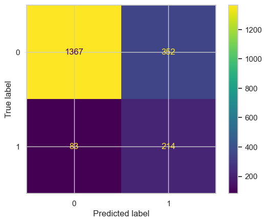

```python
# Graficamos la matriz de confusión
conf_mat = confusion_matrix(y_test, y_pred)

conf_mat_display = ConfusionMatrixDisplay(conf_mat).plot()
conf_mat_display
plt.show()
```

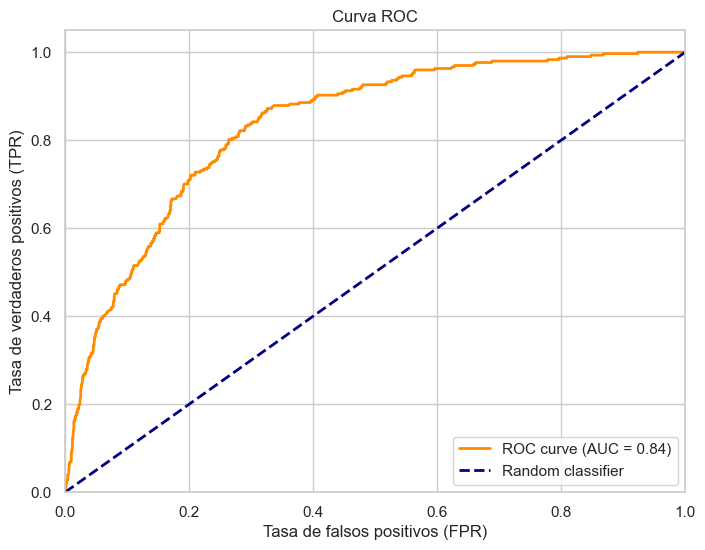

```python
# Graficamos el área de la curva ROC
fpr, tpr, thresholds = roc_curve(y_test, y_proba)

roc_auc = roc_auc_score(y_test, y_proba)

# Graficar
plt.figure(figsize=(8, 6))
plt.plot(fpr, tpr, color='darkorange', lw=2, label=f'ROC curve (AUC = {roc_auc:.2f})')
plt.plot([0, 1], [0, 1], color='navy', lw=2, linestyle='--', label='Random classifier')
plt.xlim([0.0, 1.0])
plt.ylim([0.0, 1.05])
plt.xlabel('Tasa de falsos positivos (FPR)')
plt.ylabel('Tasa de verdaderos positivos (TPR)')
plt.title('Curva ROC')
plt.legend(loc='lower right')
plt.grid(True)
plt.show()
```

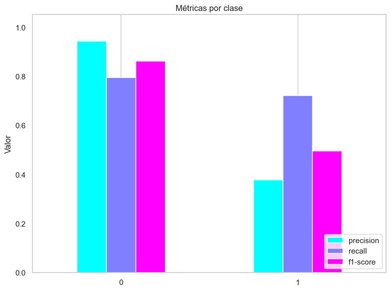

```python
# Graficamos el report
report_dict = classification_report(y_test, y_pred, output_dict=True)

df_report = pd.DataFrame(report_dict).transpose()

df_classes = df_report.loc[['0', '1'], ['precision', 'recall', 'f1-score']]

df_classes.plot(kind='bar', figsize=(8, 6), colormap='cool')
plt.title('Métricas por clase')
plt.ylabel('Valor')
plt.ylim(0, 1.05)
plt.xticks(rotation=0)
plt.grid(axis='y')
plt.legend(loc='lower right')
plt.tight_layout()
plt.show()
```

```python
# Sacamos el Feature Importance
importances = model.feature_importances_
feature_names = X_train.columns

feat_df = pd.DataFrame({'Feature': feature_names, 'Importance': importances})
feat_df = feat_df.sort_values(by='Importance', ascending=False)

feat_df
```

|  | Feature | Importance |
| --- | --- | --- |
| 0 | Year | 0.163459 |
| 4 | Region | 0.156230 |
| 2 | Disaster_Type | 0.116660 |
| 5 | Continent | 0.116433 |
| 7 | Duration_Days | 0.111166 |
| 9 | Grupo_Riqueza | 0.089100 |
| 3 | Disaster_Subtype | 0.069809 |
| 6 | Dis_Mag_Scale | 0.068940 |
| 8 | Season | 0.065928 |
| 1 | Disaster_Subgroup | 0.042274 |

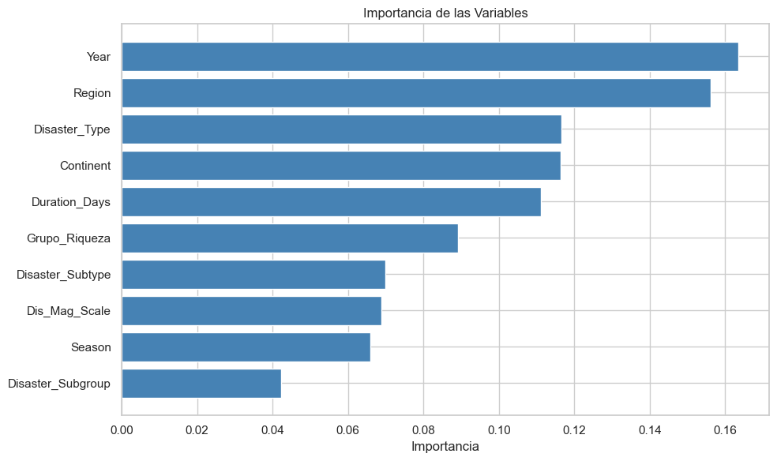

```python
plt.figure(figsize=(10, 6))
plt.barh(feat_df['Feature'], feat_df['Importance'], color='steelblue')
plt.gca().invert_yaxis()
plt.title('Importancia de las Variables')
plt.xlabel('Importancia')
plt.tight_layout()
plt.show()
```

Con lo que hemos reducido y simplificado el modelo, no se hasta que punto tendría sentido simplificarlo más. Disaster_Subgroup con un 0,04 podría eliminarse...

```python
# Tratamos de ver un mejor punto de corte o punto de corte óptimo
y_probs = model.predict_proba(X_test)[:, 1]
fpr, tpr, thresholds = roc_curve(y_test, y_probs)

youden_ind = tpr - fpr
best_idx = youden_ind.argmax()
optimal_threshold = thresholds[best_idx]

print(f"Umbral óptimo: {optimal_threshold:.2f}")
```

```
Umbral óptimo: 0.38
```

```python
thresholds = np.arange(0.0, 1.0, 0.01)
f1_scores = [f1_score(y_test, y_probs > t) for t in thresholds]

best_threshold = thresholds[np.argmax(f1_scores)]

print(f"Umbral que maximiza F1: {best_threshold:.2f}")
```

```
Umbral que maximiza F1: 0.53
```

```python
# Ajustamos a ver cómo queda
threshold = 0.38
y_pred_youden = (y_probs >= threshold).astype(int)

print("Confusion Matrix:")
print(confusion_matrix(y_test, y_pred_youden))

print("\nClassification Report:")
print(classification_report(y_test, y_pred_youden))

print("F1 Score:", f1_score(y_test, y_pred_youden))
```

```
Confusion Matrix:
[[1145  574]
 [  37  260]]

Classification Report:
              precision    recall  f1-score   support

           0       0.97      0.67      0.79      1719
           1       0.31      0.88      0.46       297

    accuracy                           0.70      2016
   macro avg       0.64      0.77      0.62      2016
weighted avg       0.87      0.70      0.74      2016

F1 Score: 0.45977011494252873
```

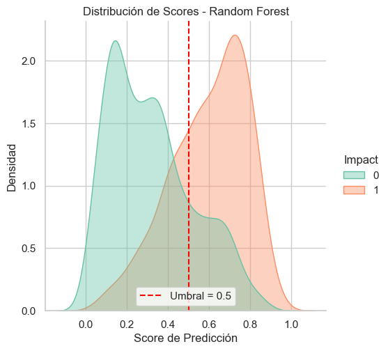

```python
df_scores = pd.DataFrame({'score': y_proba, 'Impact': y_test})
df_scores = df_scores.dropna()

sns.displot(
    data=df_scores,
    x='score',
    hue='Impact',
    kind='kde',
    fill=True,
    common_norm=False,
    alpha=0.4,
    palette='Set2'
)

plt.axvline(0.5, color='red', linestyle='--', label='Umbral = 0.5')
plt.title("Distribución de Scores - Random Forest")
plt.xlabel("Score de Predicción")
plt.ylabel("Densidad")
plt.legend()
plt.show()
```

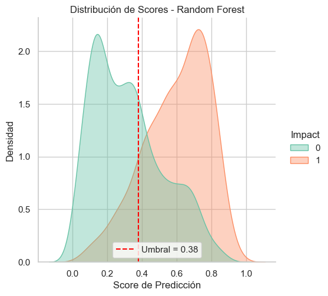

```python
df_scores_youden = pd.DataFrame({'score': y_proba, 'Impact': y_test})
df_scores_youden = df_scores_youden.dropna()

sns.displot(
    data=df_scores_youden,
    x='score',
    hue='Impact',
    kind='kde',
    fill=True,
    common_norm=False,
    alpha=0.4,
    palette='Set2'
)

plt.axvline(0.38, color='red', linestyle='--', label='Umbral = 0.38')
plt.title("Distribución de Scores - Random Forest")
plt.xlabel("Score de Predicción")
plt.ylabel("Densidad")
plt.legend()
plt.show()
```

### XGBoost

```python
model_XGB = XGBClassifier(enable_categorical=True, random_state=16)

cv_strategy = StratifiedKFold(n_splits=10, shuffle=True, random_state=16)

param_grid_XGB = {
    'n_estimators': [100, 300, 500],
    'max_depth': [3, 6, 10],
    'learning_rate': [0.01, 0.05, 0.1, 0.2],
    'subsample': [0.6, 0.8, 1.0],
    'colsample_bytree': [0.6, 0.8, 1.0],
    'gamma': [0, 1, 5],
    'reg_alpha': [0, 0.1, 1],
    'reg_lambda': [0.5, 1, 2]
}

grid_search_XGB = GridSearchCV(
    estimator=model_XGB,
    param_grid=param_grid_XGB,
    scoring='roc_auc',
    cv=cv_strategy,
    verbose=1,
    n_jobs=-1
)

grid_search_XGB.fit(X_train, y_train)
```

```
Fitting 10 folds for each of 8748 candidates, totalling 87480 fits
```

```
GridSearchCV(cv=StratifiedKFold(n_splits=10, random_state=16, shuffle=True),
             estimator=XGBClassifier(base_score=None, booster=None,
                                     callbacks=None, colsample_bylevel=None,
                                     colsample_bynode=None,
                                     colsample_bytree=None, device=None,
                                     early_stopping_rounds=None,
                                     enable_categorical=True, eval_metric=None,
                                     feature_types=None, feature_weights=None,
                                     gamma=None, grow_polic...
                                     missing=nan, monotone_constraints=None,
                                     multi_strategy=None, n_estimators=None,
                                     n_jobs=None, num_parallel_tree=None, ...),
             n_jobs=-1,
             param_grid={'colsample_bytree': [0.6, 0.8, 1.0],
                         'gamma': [0, 1, 5],
                         'learning_rate': [0.01, 0.05, 0.1, 0.2],
                         'max_depth': [3, 6, 10],
                         'n_estimators': [100, 300, 500],
                         'reg_alpha': [0, 0.1, 1], 'reg_lambda': [0.5, 1, 2],
                         'subsample': [0.6, 0.8, 1.0]},
             scoring='roc_auc', verbose=1)
```

```python
grid_search_XGB.best_params_
```

```
{'colsample_bytree': 0.6,
 'gamma': 1,
 'learning_rate': 0.05,
 'max_depth': 10,
 'n_estimators': 500,
 'reg_alpha': 1,
 'reg_lambda': 2,
 'subsample': 0.8}
```

```python
grid_search_XGB.best_score_
```

```
np.float64(0.8032749722944381)
```

```python
modelo_xgb = XGBClassifier(
    colsample_bytree=0.6,
    gamma=1,
    learning_rate=0.1,
    max_depth=3,
    n_estimators=500,
    reg_alpha=0.1,
    reg_lambda=1,
    subsample=0.8,
    use_label_encoder=False,
    eval_metric='auc',
    random_state=16
)
```

```python
modelo_xgb.fit(X_train, y_train)
```

```
XGBClassifier(base_score=None, booster=None, callbacks=None,
              colsample_bylevel=None, colsample_bynode=None,
              colsample_bytree=0.6, device=None, early_stopping_rounds=None,
              enable_categorical=False, eval_metric='auc', feature_types=None,
              feature_weights=None, gamma=1, grow_policy=None,
              importance_type=None, interaction_constraints=None,
              learning_rate=0.1, max_bin=None, max_cat_threshold=None,
              max_cat_to_onehot=None, max_delta_step=None, max_depth=3,
              max_leaves=None, min_child_weight=None, missing=nan,
              monotone_constraints=None, multi_strategy=None, n_estimators=500,
              n_jobs=None, num_parallel_tree=None, ...)
```

```python
y_pred_xgb = modelo_xgb.predict(X_test)
y_proba_xgb = modelo_xgb.predict_proba(X_test)[:, 1]

# Métricas
print("Matriz de confusión:")
print(confusion_matrix(y_test, y_pred_xgb))

print("\nReporte de clasificación:")
print(classification_report(y_test, y_pred_xgb))

print("ROC AUC:", roc_auc_score(y_test, y_proba_xgb))
```

```
Matriz de confusión:
[[1692   27]
 [ 254   43]]

Reporte de clasificación:
              precision    recall  f1-score   support

           0       0.87      0.98      0.92      1719
           1       0.61      0.14      0.23       297

    accuracy                           0.86      2016
   macro avg       0.74      0.56      0.58      2016
weighted avg       0.83      0.86      0.82      2016

ROC AUC: 0.8456094785355984
```

[figure not shown]

```python
fpr2, tpr2, _ = roc_curve(y_test, y_proba_xgb)
roc_auc2 = auc(fpr2, tpr2)

plt.figure(figsize=(8, 6))
plt.plot(fpr2, tpr2, color='darkorange', lw=2, label=f'ROC curve (AUC = {roc_auc:.2f})')
plt.plot([0, 1], [0, 1], color='navy', lw=2, linestyle='--', label='Random classifier')
plt.xlim([0.0, 1.0])
plt.ylim([0.0, 1.05])
plt.xlabel('Tasa de falsos positivos (FPR)')
plt.ylabel('Tasa de verdaderos positivos (TPR)')
plt.title('Curva ROC')
plt.legend(loc='lower right')
plt.grid(True)
plt.show()
```

```python
umbral = 0.38
y_pred_ajustado = (y_proba_xgb >= umbral).astype(int)
```

```python
print("Matriz de confusión:")
print(confusion_matrix(y_test, y_pred_ajustado))

print("\nReporte de clasificación:")
print(classification_report(y_test, y_pred_ajustado))
```

```
Matriz de confusión:
[[1641   78]
 [ 198   99]]

Reporte de clasificación:
              precision    recall  f1-score   support

           0       0.89      0.95      0.92      1719
           1       0.56      0.33      0.42       297

    accuracy                           0.86      2016
   macro avg       0.73      0.64      0.67      2016
weighted avg       0.84      0.86      0.85      2016
```

```python
importances2 = modelo_xgb.feature_importances_
feature_names2 = X_train.columns

feat_df2 = pd.DataFrame({'Feature': feature_names2, 'Importance': importances2})
feat_df2 = feat_df2.sort_values(by='Importance', ascending=False)

feat_df2
```

|  | Feature | Importance |
| --- | --- | --- |
| 5 | Continent | 0.136219 |
| 0 | Year | 0.136060 |
| 1 | Disaster_Subgroup | 0.131743 |
| 6 | Dis_Mag_Scale | 0.130702 |
| 2 | Disaster_Type | 0.127153 |
| 7 | Duration_Days | 0.095976 |
| 4 | Region | 0.071791 |
| 3 | Disaster_Subtype | 0.058606 |
| 8 | Season | 0.056717 |
| 9 | Grupo_Riqueza | 0.055033 |